# Practical machine learning course project

Turan

31 January 2016

# Part 1: Reading the data

I will first start by reading and uploading the data. Note that the testing data is untouched and will only be used for testing the results of the final model.

```r
library(caret,quietly = TRUE)

#Enter directory where you installed the data below
trainingpath="C:/Coursera/pml-training.csv"
testingpath="C:/Coursera/pml-testing.csv"

mainData=read.csv(trainingpath)
FinaltestingData=read.csv(testingpath)
```

# Part 2: Partition the data and Cross Validation

After reading the data, I will partition the data into training and testing. Training will be used to train the models and testing will be used to test the strength of each model tested.

```r
set.seed(42) #setting the seed for reproducibility

partitionIndex=createDataPartition(mainData$classe,p=0.7,list = FALSE)
training=mainData[partitionIndex,]
testing=mainData[-partitionIndex,]
```

Please note that with further partitioning the data into 70/30 percent partitions, I am implicitly using Random sub sampling.

# Part 3: Data preprocessing

There are are 160 variables in the training set. In this part, I will look at the summary statistics of these variables to confine the data set so that it is ready for modeling. Some of the results of the codes are very length therefore for some parts only the code is submitted.

```r
summary(training)
```

The summary of the variables suggest that the following variables can be excluded due to too many missing values or too many #Div/0 or empty values. Excluding these variables, the data source reduces to 58 variables (including the prediction variable). The code for this part is as follows:

```r
training2=training[,-c(1:2,12:36,50:59,69:83,87:101,103:112,125:139,141:150)]
summary(training2)
```

The summary on training2 revealed that all the variables having 97% or more missing values are eliminated from the data set.

# Part 4: Model Building

```r
model1=train(factor(classe)~.,method="rpart",data=training2)
```

The results of the *model1* is illustrated in the appendix.

Next I will predict new variables as

```r
confusionMatrix(predict(model1,newdata=testing[,-160]),testing[,160])
```

```
## Confusion Matrix and Statistics
##
##           Reference
## Prediction    A    B    C    D    E
##          A 1258  281   29   43   18
##          B  118  494   14    0    0
##          C   95  187  543   23   63
##          D  198  177  440  898  517
##          E    5    0    0    0  484
##
## Overall Statistics
##
##                Accuracy : 0.6248
##                  95% CI : (0.6123, 0.6372)
##     No Information Rate : 0.2845
##     P-Value [Acc > NIR] : < 2.2e-16
##
##                   Kappa : 0.5289
##  Mcnemar's Test P-Value : NA
##
## Statistics by Class:
##
##                      Class: A Class: B Class: C Class: D Class: E
## Sensitivity            0.7515  0.43371  0.52924   0.9315  0.44732
## Specificity            0.9119  0.97219  0.92426   0.7293  0.99896
## Pos Pred Value         0.7723  0.78914  0.59605   0.4027  0.98978
## Neg Pred Value         0.9023  0.87735  0.90290   0.9819  0.88918
## Prevalence             0.2845  0.19354  0.17434   0.1638  0.18386
## Detection Rate         0.2138  0.08394  0.09227   0.1526  0.08224
## Detection Prevalence   0.2768  0.10637  0.15480   0.3789  0.08309
## Balanced Accuracy      0.8317  0.70295  0.72675   0.8304  0.72314
```

Next I will apply these results 20 cases that will be used in the quiz.

```r
predict(model1,newdata = FinaltestingData)
```

```
##  [1] D C C A A D D C A A B C B A D D D B D B
## Levels: A B C D E
```

# Appendix:

*Figure 1: Rpart plot*

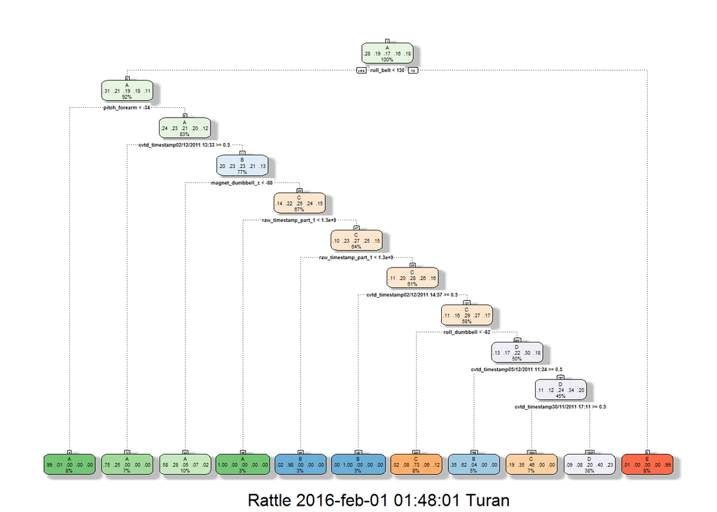